# Setting up an Ubuntu AWS EC2 Instance from a Windows Machine

Although windows has improved their command line woes with WSL, I found it incredibly difficult to spin up an EC2 instance on my windows machine at the time of this post.

If you're in a similiar boat as I was, with hours of scouring the internet behind you and still no EC2 instance in front of you, then this post is for you.

- What is an AWS EC2 Instance?
- Pricing
- Step 1: Sign in or Sign Up
- Step 2: Request a Service Limit
- Step 3: Create an EC2 Instance
- Step 4: Connect to Your Instance
- Step 5: Setting up your Instance
- Step 6: Stop your Instance
- Copying Files from S3 Bucket
- Upload Files from EC2 to S3 Bucket

# What is an AWS EC2 Instance?

An EC2 instance is a virtual server hosted on Amazon [Elastic Compute Cloud (EC2)](https://aws.amazon.com/ec2/).

These virtual servers provide users access to insanely fast computing power that they otherwise wouldn't have access outside of purchasing a high-performance GPU. Which, at the time of this post, will cost you around $2,500.

# Pricing

You're going to want an accelerated computing instance family for machine learning. For our purposes, I'm going to recommend a `g4dn.xlarge` instance, which will provide enough compute power for most machine learning tasks.

At the time of this post, a `gfdn.xlarge` instance is [$0.526/hr](https://aws.amazon.com/ec2/instance-types/g4/).

Now that we have an overview of EC2 instances, lets dive into the details of setting one up.

# Step 1: Sign in or Sign Up

If you already have an AWS account, visit the [AWS webpage](https://aws.amazon.com/) and click "Sign into Console", make sure you are logging in as an IAM user and not the root user for security reasons. If you do not have an IAM user setup, follow this [guide](https://docs.aws.amazon.com/AmazonS3/latest/userguide/setting-up-s3.html#create-an-iam-user-gsg).

If you do not have an AWS account, visit the [AWS webpage](https://aws.amazon.com/) press 'Sign Up' then enter an account name and password. You will also be asked to enter information of the credit card that will be charged for instance usage, as well as your phone number which they will use to verify your identity. After you've created your account, sign in as the root user then follow this [guide](https://docs.aws.amazon.com/AmazonS3/latest/userguide/setting-up-s3.html#create-an-iam-user-gsg) to create an IAM user. Then sign in as your IAM user.

# Step 2: Request a Service Limit

For the gfdn.xlarge instance, you're going to have to request a limit increase beyond the default of 0. First, type in 'EC2' into the search bar of the management console and press enter.

Next, choose "*Limits*" on the left hand pane:

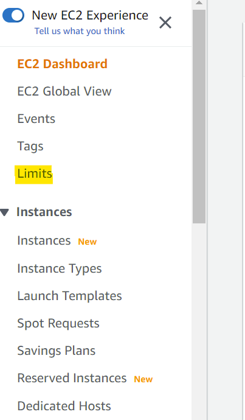

Then, under "*Find limits*" search for "*All g*" and select "*Running On-Demand All G and VT instances*".

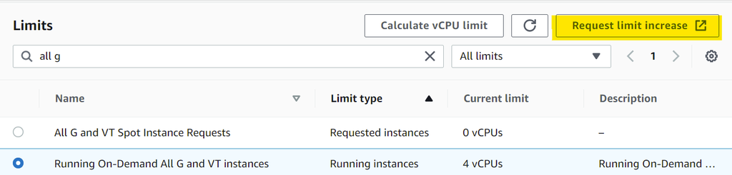

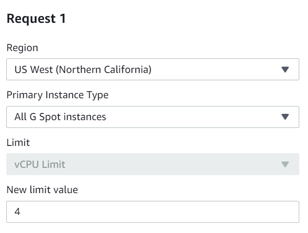

Under the use case description, add a description for your limit increase such as "Hit maximum limit of launching instances. Please add more." Then, submit your request.

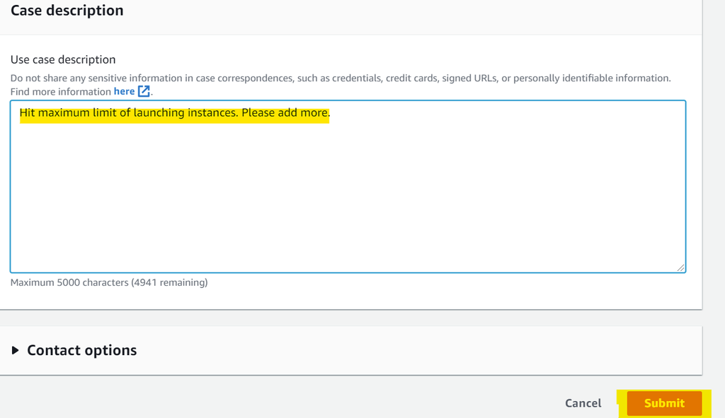

You should receive an automatic reply in your email saying that they received your request. Then (hopefully) an approval notice within a few hours.

# Step 3: Create an EC2 Instance

Type "*EC2*" into the search bar and go to the EC2 Dashboard in the left pane. Scroll down until you can select "*Launch Instance*".

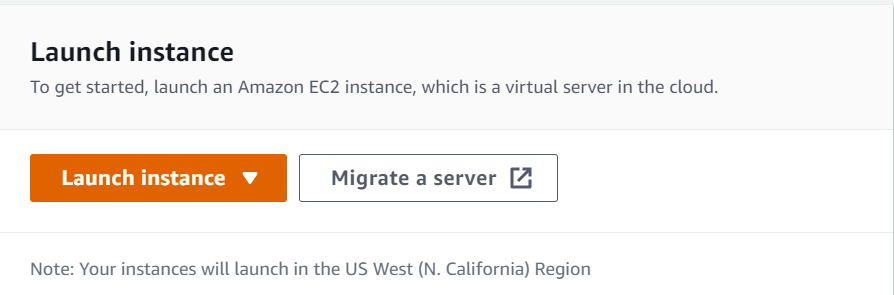

Type "*Ubuntu*" into the search bar then select the AMI titled "*Ubuntu Server 20.04 LTS (HVM), SSD Volume Type"*.

[figure not shown]

Select the "*g4dn.xlarge*" instance type then hit "*Review and Launch*".

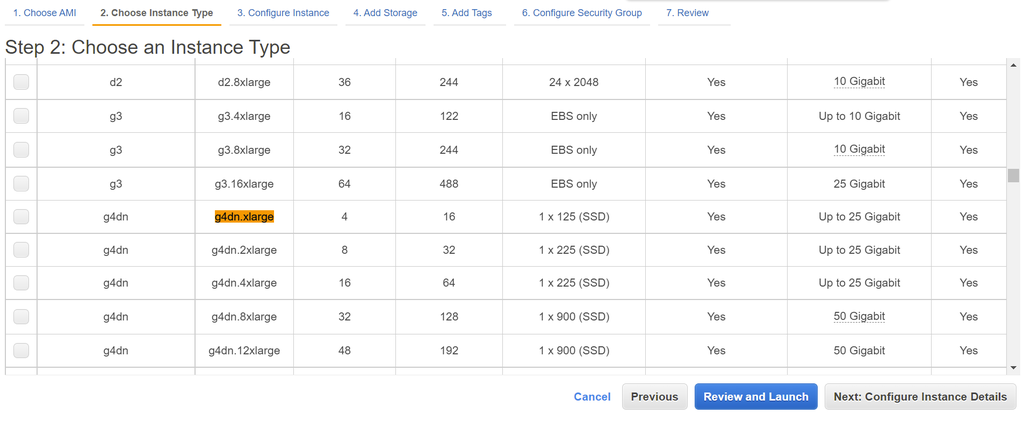

Next, select "**Create a new key pair**", give it a name, and download it.

**Make sure your private key file (.pem file) is stored in a secure and accessible location. You will never be able to download the file again. Without access to the file you will not be able to access your instance.**

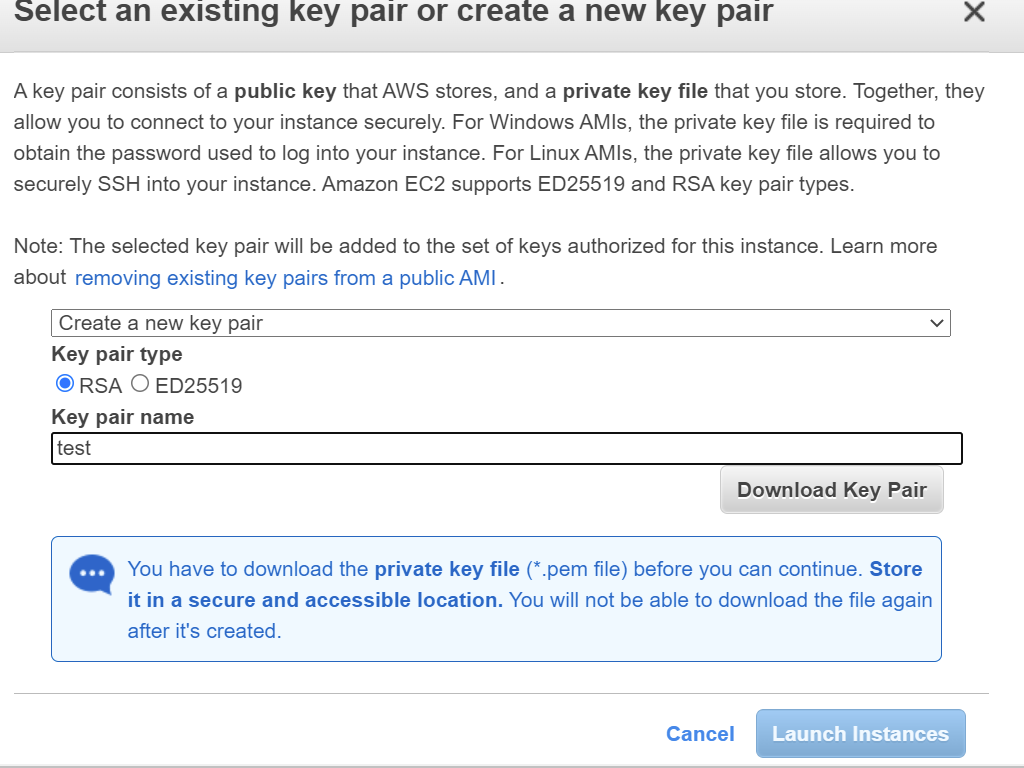

# Step 4: Connect to Your Instance

At the bottom of the screen, click "*view instances*". You'll see that you have an instance that says "*running*" under the instance state.

Select this instance then find your instances "*Public DNS*" and copy it.

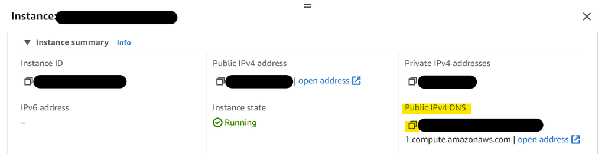

Next open a command line terminal on your local computer. I'd recommend using [Git for Windows](https://git-scm.com/download/win).

In the terminal use these commands to change the directory to where your security key from Step 3 is located. Change the text in brackets <> to fit your specific file structure, filename, and instance DNS. You'll also want to remove the brackets.

```
cd/Users/<your_username>/<Downloads>/

chmod 0400 <your .pem filename>

ssh -L localhost:8888:localhost:8888 -i <your .pem filename> ubuntu@ <your instance DNS>
```

You'll be asked if you want to continue connecting, type yes unless you realized that all this work was for nothing.

A successful connection will be realized if you see **ubuntu@ip-xxx-xx-x-xxx** on the active line of your command line terminal where -xxx-xx-x-xxx is your IP.

# Step 5: Setting up your Instance

In order to train machine learning models on our instance, we're going to need some packages. To get started, let's install anaconda by following this excellent [guide](https://linuxize.com/post/how-to-install-anaconda-on-ubuntu-20-04/). For any other packages, I'm sure you can figure it out.

# Step 6: Stop your Instance

It's important to stop your instance when you're no longer using it since AWS charges you for each hour you use it. To do so, go to the EC2 dashboard and select your instance. Then under '**Instance State**' select '**Stop Instance**'.

[figure not shown]

# Copying Files from S3 Bucket

Now that you have your EC2 instance setup, you'll most likely want to interact with files you have stored locally. The easiest way I've found to do this is to copy those files to an S3 bucket and interact with them from there.

First, create an S3 bucket, then run the following command in your ec2 instance:

```
aws s3 sync s3://remote_S3_bucket local_directory
```

where local_directory is the directory name you want to store the files in the s3 bucket under. If you're unfamiliar with creating a S3 bucket, follow [this guide](https://docs.aws.amazon.com/AmazonS3/latest/userguide/creating-bucket.html). In step 6 of the guide, you can uncheck "Block *all* public access" if you are not concerned with security. If security is of concern, follow [this guide](https://aws.amazon.com/premiumsupport/knowledge-center/ec2-instance-access-s3-bucket/) to allow your EC2 instance access to your S3 bucket.

# Upload Files from EC2 to S3 Bucket

Once your machine project is done, you might want to download the updated files onto your local machine. To do this, you'll need to upload the files from your EC2 instance to your S3 bucket, then download them from there. You can achieve this by running this command while connected to your EC2 instance:

[output not shown]

Where SOURCE_DIR is the directory you're copying from your EC2 instance and DEST_BUCKET is the S3 bucket you want to upload to. Now that the files are uploaded, you can download them to your local machine.